# HW3-shiyuchen-21210980116

Shi Yuchen

3/23/2022

## 数据说明

本案例所采用数据为“data.csv”文件为北京外卖商家销量数据，数据集包含了32043条商家信息，为2017年8月从北京地区某外卖平台爬取的数据。每一条观测数据为一个商家的信息，变量包括月销量、平均每单价格、配送方式、配送费等。自变量共分为五个维度，分别为外卖商户基本信息、评分信息、位置信息、优惠信息和衍生字段信息，具体信息如下表所示。

字段对照： 1．基本信息： delivery_mode(商家配送方式)；float_delivery_fee(配送费)；float_minimum_order_amount(起送价)；is_new(是否新店)；is_premium(是否品牌店)；order_lead_time(配送时间)；recent_order_num(月销量)；average_cost(平均每单费用)；保(是否支持外卖保)；票(是否可开发票)；open_time(每天营业时长，单位：小时)；open08(8点是否营业)；open12(12点是否营业)；open18(18点是否营业)；open23(23点是否营业)；shop_type(商家分类) 2．评分信息： compare_rating(比较评分，通过和周边商家对比得到的得分)；food_score(食物评分)；service_score(服务评分)；star_level(星级)； 3．位置信息 district(行政区划1，包含北京全部16个行政区)；district0(行政区划2，其中将北京城六区外的其他区合并为非城区)； 4．优惠信息 manjian_discount(满减折扣率)；new_user(新用户减免)；other_activities(其他活动数量，除了满减和新用户减免外的其他活动)； 5．衍生字段信息 log_recent_order_num(对数月销量：月销量加1再取对数)；log_average_cost(对数平均每单费用：平均每单费用加1再取对数)；log_float_delivery_fee(对数配送费：配送费加1再取对数)；

## 分析任务

1. 读入数据，查看数据情况；
2. 绘制对数月销量的直方图，观察其特征，并作出解释；
3. 绘制行政区划与月销量对比箱线图，并作出解释（要求箱线图的箱子按中位数大小排列）；
4. 绘制四个用餐高峰期是否营业（open08、open12、open18、open23）与对数月销量对比箱线图（四个子图）。要求：在一张大图中放入四个子图（提示：使用基础绘图函数时可用par参数，使用ggplot2时使用facet_wrap分面或者ggpubr包中的ggarrange函数）；
5. 建立回归模型，使用BIC准则进行逐步回归得到最终模型，查看最终模型中的系数大小及其显著性，并解读系数。要求：
1. 因变量：对数月销量
2. 自变量：对数平均每单费用、配送模式、对数配送费、对数起送费、起送时间、所在行政区（北京市16区）、是否有外卖保、是否开发票、满减折扣率、其他优惠活动数、新用户减免、每天营业时长、8点是否营业、12点是否营业、16点是否营业、23点是否营业、商家分类、是否新店、是否品牌店
3. 对于行政区划变量，使用昌平区作为基准水平；
4. 对于商家分类变量，使用果蔬生鲜作为基准水平；
6. 从模型中提取出行政区变量的系数与显著性，分别绘制系数柱状图，要求：
1. 回归系数按数值大小排列；
2. 显著与不显著使用不同颜色标注；
7. 假设你要开一家外卖店，并有如下打算，请预测其未来的（已经不是新店）月销量。
1. 在长宁区经营快餐简餐（非品牌店），目标客户是学生党，平均每单费用约为20元（可参考北京与长宁区定位相似的行政区）；
2. 使用蜂鸟专送，配送费6元，配送时间约为45分钟；
3. 不可开发票；
4. 综合评分(new_score)约为0.65分；
5. 满减折扣率约为35%、其他活动数5个、没有新用户减免；
6. 每天营业11小时，且在18点和23点都营业。

## 数据概况

1. 读入数据，查看数据情况；

```r
raw_data = read.csv('data.csv', encoding='UTF-8')
head(raw_data)
```

```
##   delivery_mode float_delivery_fee float_minimum_order_amount is_new is_premium
## 1      商家配送                  7                          0  False      False
## 2      蜂鸟专送                  5                         20  False       True
## 3      商家配送                  6                         20  False       True
## 4      商家配送                 10                         20  False      False
## 5      商家配送                  7                         30  False      False
## 6      商家配送                  5                         30  False      False
##   order_lead_time recent_order_num compare_rating food_score service_score
## 1              45             2123      0.4948689    4.50012       4.47928
## 2              35             4546      0.7005511    4.61939       4.74763
## 3              51             1194      0.4664587    4.61707       4.47224
## 4              44              375      0.3758566    4.81023       4.70941
## 5              38             6664      0.5331492    4.60685       4.56124
## 6              25               54      0.9563925    4.92060       5.00000
##   star_level district manjian_discount new_user other_activities average_cost
```

[output cut: 27 more lines]

```r
# 数据类型
data = raw_data
data$is_new = as.logical(data$is_new)
data$is_premium = as.logical(data$is_premium)

# table(data$open12)
# 0/1
for (name in c('open08', 'open12', 'open18', 'open23', 'delivery_mode', "district", "district0", "shop_type")) {
  data[[name]] = as.factor(data[[name]])
}
summary(data)
```

```
##   delivery_mode   float_delivery_fee float_minimum_order_amount   is_new
##  商家配送:18553   Min.   :  0.000    Min.   :  0.00             Mode :logical
##  蜂鸟专送:13490   1st Qu.:  5.000    1st Qu.: 20.00             FALSE:29317
##                   Median :  7.000    Median : 20.00             TRUE :2726
##                   Mean   :  8.355    Mean   : 22.87
##                   3rd Qu.:  9.000    3rd Qu.: 20.00
##                   Max.   :200.000    Max.   :500.00
##
##  is_premium      order_lead_time recent_order_num  compare_rating
##  Mode :logical   Min.   : 0.00   Min.   :    0.0   Min.   :-1.0000
##  FALSE:27785     1st Qu.:26.00   1st Qu.:   45.0   1st Qu.: 0.2792
##  TRUE :4258      Median :31.00   Median :  124.0   Median : 0.5148
##                  Mean   :30.32   Mean   :  465.7   Mean   : 0.4472
##                  3rd Qu.:37.00   3rd Qu.:  452.0   3rd Qu.: 0.7396
##                  Max.   :80.00   Max.   :13571.0   Max.   : 0.9889
##
##    food_score     service_score      star_level        district
##  Min.   :-1.000   Min.   :-1.000   Min.   :-1.000   朝阳区 :9369
##  1st Qu.: 4.341   1st Qu.: 4.401   1st Qu.: 4.400   海淀区 :5130
##  Median : 4.538   Median : 4.643   Median : 4.600   昌平区 :2928
##  Mean   : 4.188   Mean   : 4.272   Mean   : 4.237   丰台区 :2737
##  3rd Qu.: 4.732   3rd Qu.: 4.834   3rd Qu.: 4.800   通州区 :2304
##  Max.   : 5.000   Max.   : 5.000   Max.   : 5.000   大兴区 :2085
##                                                     (Other):7490
##  manjian_discount    new_user     other_activities   average_cost
##  Min.   :0.0000   Min.   : 0.00   Min.   : 0.0000   Min.   :     0.0
##  1st Qu.:0.0100   1st Qu.:17.00   1st Qu.: 0.0000   1st Qu.:    27.5
##  Median :0.1667   Median :20.00   Median : 0.0000   Median :    38.5
##  Mean   :0.1975   Mean   :19.16   Mean   : 0.9727   Mean   :    77.1
##  3rd Qu.:0.3231   3rd Qu.:21.00   3rd Qu.: 1.0000   3rd Qu.:    57.6
##  Max.   :0.9583   Max.   :45.00   Max.   :30.0000   Max.   :655873.9
##
##      保              票          log_recent_order_num log_average_cost
##  Mode :logical   Mode :logical   Min.   :0.000        Min.   : 0.000
##  FALSE:8359      FALSE:23572     1st Qu.:3.829        1st Qu.: 3.349
##  TRUE :23684     TRUE :8471      Median :4.828        Median : 3.677
##                                  Mean   :4.758        Mean   : 3.543
##                                  3rd Qu.:6.116        3rd Qu.: 4.070
##                                  Max.   :9.516        Max.   :13.394
##
##  log_float_minimum_order_amount log_float_delivery_fee   open_time
##  Min.   :0.000                  Min.   :0.000          Min.   : 0.00
##  1st Qu.:3.045                  1st Qu.:1.792          1st Qu.:10.83
##  Median :3.045                  Median :2.079          Median :11.75
##  Mean   :2.958                  Mean   :2.101          Mean   :11.90
##  3rd Qu.:3.045                  3rd Qu.:2.303          3rd Qu.:12.50
##  Max.   :6.217                  Max.   :5.303          Max.   :24.00
##
##  open08    open12    open18    open23       shop_type        district0
##  0:30260   0: 1214   0:  494   0:27122   小吃夜宵: 5474   东城区  : 1659
##  1: 1783   1:30829   1:31549   1: 4921   异国料理: 1953   丰台区  : 2737
##                                          快餐简餐:14097   朝阳区  : 9369
##                                          果蔬生鲜: 1770   海淀区  : 5130
##                                          特色菜系: 6678   石景山区:  746
##                                          甜品饮品: 2071   西城区  : 1684
##                                                           非城区  :10718
```

2. 绘制对数月销量的直方图，观察其特征，并作出解释；

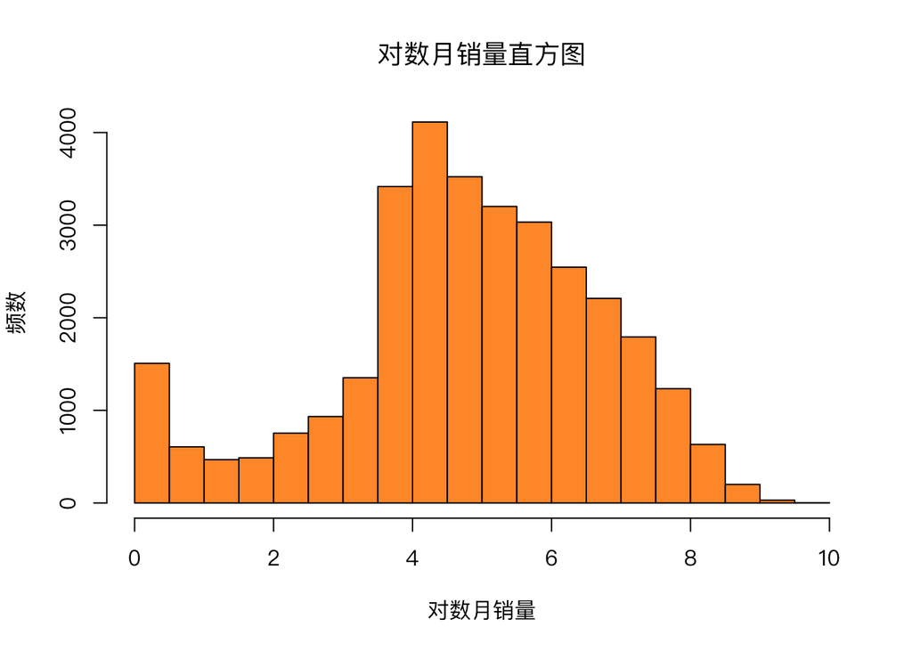

```r
par(family="PingFangSC-Regular")
hist(raw_data$log_recent_order_num, freq = T, main = "对数月销量直方图", col = "#FF9933", xlab = "对数月销量", ylab = "频数")
```

观察对数月销量的分布, 有较多的商家月销量在4-7之间, 而少数商家月销量在8以上, 另有一部分商家的对数月销量不足2, 销量较少. 从总体来看, 除去少量销量较低的商家之外, 总体来看对数月销量呈现右偏.

3. 绘制行政区划与月销量对比箱线图，并作出解释（要求箱线图的箱子按中位数大小排列）；

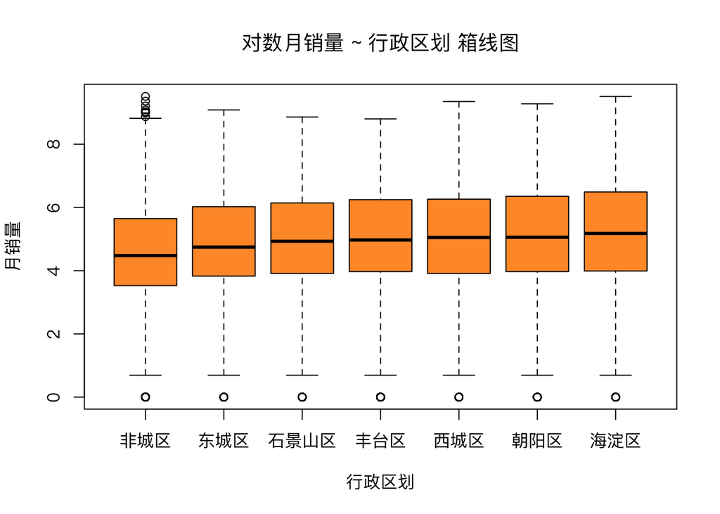

```r
par(family="PingFangSC-Regular")
# reorder district0
new_order <- with(data, reorder(district0, log_recent_order_num, median))
boxplot(log_recent_order_num ~ new_order, data=data, main = "对数月销量 ~ 行政区划 箱线图", xlab = "行政区划", ylab = "月销量", col = "#FF9933")
```

从上图中可以看到, 不同行政区划的商家月销量存在差异. 非城区的商家月销量明显小于北京城六区; 其中销量最高的城区为海淀区.

4. 绘制四个用餐高峰期是否营业（open08、open12、open18、open23）与对数月销量对比箱线图（四个子图）。要求：在一张大图中放入四个子图（提示：使用基础绘图函数时可用par参数，使用ggplot2时使用facet_wrap分面或者ggpubr包中的ggarrange函数）；

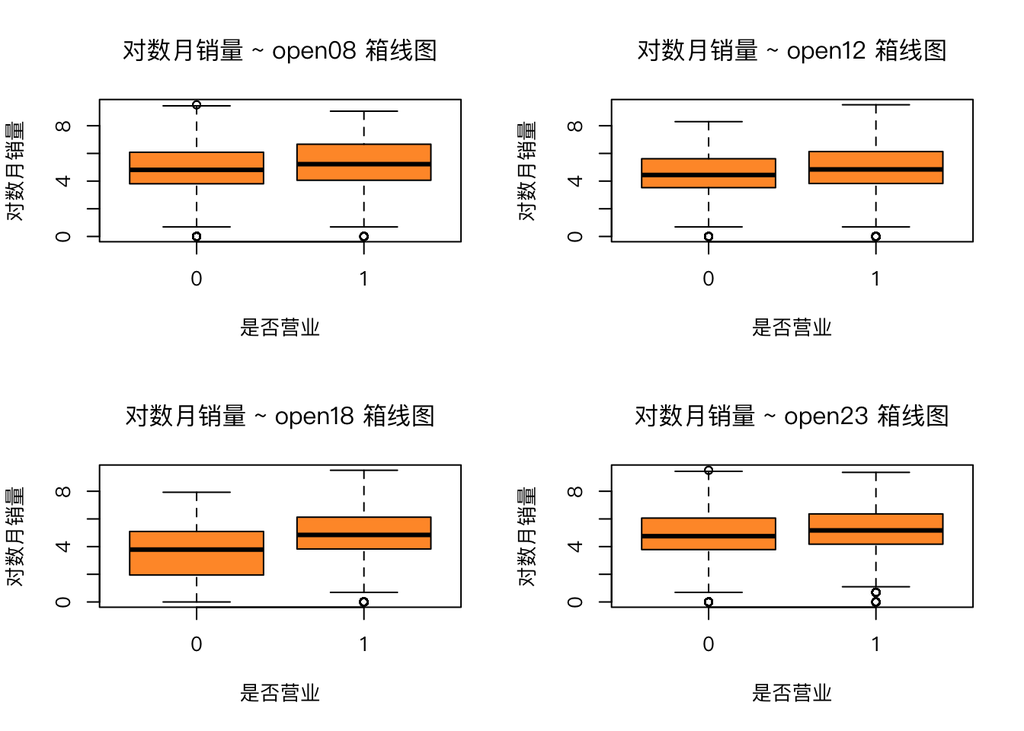

```r
par(family="PingFangSC-Regular", mfrow = c(2, 2))

for (time in c("open08", "open12", "open18", "open23")) {
  boxplot(data$log_recent_order_num ~ data[, time], data=data, main=paste0("对数月销量 ~ ", time, " 箱线图"), xlab = "是否营业", ylab = "对数月销量", col = "#FF9933")
}
```

从四张图中可以看到, 是否在高峰期间营业对于月销量有一定的影响: 在四个时间段, 营业的商家月销量均高于不营业的商家. 其中最为显著的是16点是否营业 (也即晚饭时段) 这一因子, 在这一高峰期选择营业的店家月销量要明显高于不营业的商家.

## 回归模型

5. 建立回归模型，使用BIC准则进行逐步回归得到最终模型，查看最终模型中的系数大小及其显著性，并解读系数。要求：
1. 因变量：对数月销量
2. 自变量：对数平均每单费用、配送模式、对数配送费、对数起送费、起送时间、所在行政区（北京市16区）、是否有外卖保、是否开发票、满减折扣率、其他优惠活动数、新用户减免、每天营业时长、8点是否营业、12点是否营业、16点是否营业、23点是否营业、商家分类、是否新店、是否品牌店
3. 对于行政区划变量，使用昌平区作为基准水平；
4. 对于商家分类变量，使用果蔬生鲜作为基准水平；

```r
# set reference level
data$shop_type = relevel(as.factor(data$shop_type), ref="果蔬生鲜")
data$district = relevel(as.factor(data$district), ref="昌平区")

model_full = lm(
  log_recent_order_num ~ log_average_cost+delivery_mode+log_float_delivery_fee+log_float_minimum_order_amount+order_lead_time+
    district+保+票+manjian_discount+other_activities+new_user+open_time+open08+open12+open18+open23+
      shop_type+is_new+is_premium, data
  )
summary(model_full)
```

```
##
## Call:
## lm(formula = log_recent_order_num ~ log_average_cost + delivery_mode +
##     log_float_delivery_fee + log_float_minimum_order_amount +
##     order_lead_time + district + 保 + 票 + manjian_discount +
##     other_activities + new_user + open_time + open08 + open12 +
##     open18 + open23 + shop_type + is_new + is_premium, data = data)
##
## Residuals:
##     Min      1Q  Median      3Q     Max
## -5.9349 -0.8153  0.0617  0.8994  4.3916
##
## Coefficients:
##                                 Estimate Std. Error t value Pr(>|t|)
## (Intercept)                     0.555263   0.103905   5.344 9.16e-08 ***
## log_average_cost                0.266842   0.007348  36.315  < 2e-16 ***
## delivery_mode蜂鸟专送          -0.163623   0.019173  -8.534  < 2e-16 ***
## log_float_delivery_fee         -0.309642   0.017478 -17.717  < 2e-16 ***
## log_float_minimum_order_amount -0.006716   0.009966  -0.674 0.500401
## order_lead_time                 0.038597   0.000669  57.695  < 2e-16 ***
## district东城区                 -0.126423   0.042817  -2.953 0.003153 **
## district丰台区                  0.037726   0.036461   1.035 0.300824
## district大兴区                 -0.031652   0.039360  -0.804 0.421299
## district密云区                 -0.570341   0.091147  -6.257 3.97e-10 ***
## district平谷区                 -0.043142   0.086883  -0.497 0.619508
## district延庆区                  0.140768   0.114276   1.232 0.218024
## district怀柔区                 -0.287581   0.081611  -3.524 0.000426 ***
## district房山区                 -0.396542   0.055057  -7.202 6.05e-13 ***
## district朝阳区                  0.034924   0.029523   1.183 0.236834
## district海淀区                  0.010957   0.031695   0.346 0.729564
## district石景山区                0.084339   0.054727   1.541 0.123306
## district西城区                 -0.054247   0.042251  -1.284 0.199174
## district通州区                  0.283771   0.037405   7.586 3.38e-14 ***
## district门头沟区                0.297286   0.091554   3.247 0.001167 **
## district顺义区                 -0.183918   0.044622  -4.122 3.77e-05 ***
## 保TRUE                          0.110541   0.024034   4.599 4.25e-06 ***
## 票TRUE                          0.263976   0.018889  13.975  < 2e-16 ***
## manjian_discount                3.911180   0.049186  79.518  < 2e-16 ***
## other_activities                0.093194   0.004535  20.550  < 2e-16 ***
## new_user                        0.001198   0.002354   0.509 0.610846
## open_time                       0.062182   0.004823  12.893  < 2e-16 ***
## open081                        -0.028024   0.043670  -0.642 0.521053
## open121                         0.005202   0.051842   0.100 0.920074
## open181                         0.343339   0.066238   5.183 2.19e-07 ***
## open231                         0.111026   0.030873   3.596 0.000323 ***
## shop_type小吃夜宵               0.739152   0.041803  17.682  < 2e-16 ***
## shop_type异国料理               0.633310   0.047377  13.367  < 2e-16 ***
## shop_type快餐简餐               0.919751   0.040043  22.969  < 2e-16 ***
## shop_type特色菜系               0.447415   0.041034  10.904  < 2e-16 ***
## shop_type甜品饮品               0.437965   0.047284   9.262  < 2e-16 ***
## is_newTRUE                     -1.474400   0.028790 -51.212  < 2e-16 ***
## is_premiumTRUE                  0.915124   0.026312  34.780  < 2e-16 ***
## ---
## Signif. codes:  0 '***' 0.001 '**' 0.01 '*' 0.05 '.' 0.1 ' ' 1
##
## Residual standard error: 1.331 on 32005 degrees of freedom
## Multiple R-squared:  0.5346, Adjusted R-squared:  0.5341
## F-statistic: 993.7 on 37 and 32005 DF,  p-value: < 2.2e-16
```

```r
# BIC
library(MASS)
model_bic = MASS::stepAIC(model_full, k = log(nrow(data)))
```

```
## Start:  AIC=18657.48
## log_recent_order_num ~ log_average_cost + delivery_mode + log_float_delivery_fee +
##     log_float_minimum_order_amount + order_lead_time + district +
##     保 + 票 + manjian_discount + other_activities + new_user +
##     open_time + open08 + open12 + open18 + open23 + shop_type +
##     is_new + is_premium
##
##                                  Df Sum of Sq   RSS   AIC
## - open12                          1       0.0 56658 18647
## - new_user                        1       0.5 56659 18647
## - open08                          1       0.7 56659 18648
## - log_float_minimum_order_amount  1       0.8 56659 18648
## <none>                                        56658 18658
## - open23                          1      22.9 56681 18660
## - 保                              1      37.5 56696 18668
## - open18                          1      47.6 56706 18674
## - delivery_mode                   1     128.9 56787 18720
## - district                       15     513.5 57172 18791
## - open_time                       1     294.3 56953 18813
## - 票                              1     345.8 57004 18842
## - log_float_delivery_fee          1     555.7 57214 18960
## - other_activities                1     747.6 57406 19067
## - shop_type                       5    1696.5 58355 19551
## - is_premium                      1    2141.4 58800 19836
## - log_average_cost                1    2334.7 58993 19941
## - is_new                          1    4642.9 61301 21171
## - order_lead_time                 1    5892.7 62551 21818
## - manjian_discount                1   11193.9 67852 24424
##
## Step:  AIC=18647.12
## log_recent_order_num ~ log_average_cost + delivery_mode + log_float_delivery_fee +
##     log_float_minimum_order_amount + order_lead_time + district +
##     保 + 票 + manjian_discount + other_activities + new_user +
##     open_time + open08 + open18 + open23 + shop_type + is_new +
##     is_premium
##
##                                  Df Sum of Sq   RSS   AIC
## - new_user                        1       0.5 56659 18637
## - open08                          1       0.8 56659 18637
## - log_float_minimum_order_amount  1       0.8 56659 18637
```

[output cut: 76 more lines]

```
## - open23                  1      29.8 56690 18624
## - 保                      1      38.1 56698 18628
## - open18                  1      54.0 56714 18637
## - delivery_mode           1     130.2 56791 18680
## - district               15     532.2 57192 18761
## - 票                      1     346.9 57007 18802
## - log_float_delivery_fee  1     564.1 57224 18924
## - open_time               1     579.6 57240 18933
## - other_activities        1     752.0 57412 19029
## - shop_type               5    1724.6 58385 19526
## - is_premium              1    2307.6 58968 19886
## - log_average_cost        1    2345.8 59006 19907
## - is_new                  1    4809.9 61470 21218
## - order_lead_time         1    5992.7 62653 21828
## - manjian_discount        1   11430.6 68091 24495
```

```r
# step(model_full, k=log(nrow(data)))
```

```r
summary(model_bic)
```

```
##
## Call:
## lm(formula = log_recent_order_num ~ log_average_cost + delivery_mode +
##     log_float_delivery_fee + order_lead_time + district + 保 +
##     票 + manjian_discount + other_activities + open_time + open18 +
##     open23 + shop_type + is_new + is_premium, data = data)
##
## Residuals:
##     Min      1Q  Median      3Q     Max
## -5.9367 -0.8157  0.0620  0.9003  4.3921
##
## Coefficients:
##                          Estimate Std. Error t value Pr(>|t|)
## (Intercept)             0.5631725  0.0857889   6.565 5.30e-11 ***
## log_average_cost        0.2668911  0.0073315  36.403  < 2e-16 ***
## delivery_mode蜂鸟专送  -0.1640758  0.0191332  -8.575  < 2e-16 ***
## log_float_delivery_fee -0.3102244  0.0173775 -17.852  < 2e-16 ***
## order_lead_time         0.0386588  0.0006644  58.184  < 2e-16 ***
## district东城区         -0.1260826  0.0427856  -2.947  0.00321 **
## district丰台区          0.0371510  0.0364244   1.020  0.30776
## district大兴区         -0.0314157  0.0393380  -0.799  0.42452
## district密云区         -0.5858945  0.0864320  -6.779 1.23e-11 ***
## district平谷区         -0.0640392  0.0806954  -0.794  0.42744
## district延庆区          0.1195407  0.1086993   1.100  0.27145
## district怀柔区         -0.3024593  0.0753948  -4.012 6.04e-05 ***
## district房山区         -0.3978019  0.0550011  -7.233 4.84e-13 ***
## district朝阳区          0.0345394  0.0294999   1.171  0.24167
## district海淀区          0.0104325  0.0316719   0.329  0.74186
## district石景山区        0.0839381  0.0547053   1.534  0.12495
## district西城区         -0.0544237  0.0422201  -1.289  0.19739
## district通州区          0.2839959  0.0373852   7.596 3.13e-14 ***
## district门头沟区        0.2970940  0.0915206   3.246  0.00117 **
## district顺义区         -0.1842610  0.0445789  -4.133 3.58e-05 ***
## 保TRUE                  0.1101934  0.0237518   4.639 3.51e-06 ***
## 票TRUE                  0.2635722  0.0188281  13.999  < 2e-16 ***
## manjian_discount        3.9118711  0.0486803  80.358  < 2e-16 ***
## other_activities        0.0930431  0.0045140  20.612  < 2e-16 ***
## open_time               0.0610309  0.0033728  18.095  < 2e-16 ***
## open181                 0.3536137  0.0640169   5.524 3.34e-08 ***
## open231                 0.1109112  0.0270153   4.105 4.04e-05 ***
## shop_type小吃夜宵       0.7420333  0.0412015  18.010  < 2e-16 ***
## shop_type异国料理       0.6365183  0.0472139  13.482  < 2e-16 ***
## shop_type快餐简餐       0.9234872  0.0397257  23.247  < 2e-16 ***
## shop_type特色菜系       0.4506565  0.0407715  11.053  < 2e-16 ***
## shop_type甜品饮品       0.4407513  0.0471023   9.357  < 2e-16 ***
## is_newTRUE             -1.4763716  0.0283226 -52.127  < 2e-16 ***
## is_premiumTRUE          0.9139038  0.0253116  36.106  < 2e-16 ***
## ---
## Signif. codes:  0 '***' 0.001 '**' 0.01 '*' 0.05 '.' 0.1 ' ' 1
##
## Residual standard error: 1.33 on 32009 degrees of freedom
## Multiple R-squared:  0.5346, Adjusted R-squared:  0.5341
## F-statistic:  1114 on 33 and 32009 DF,  p-value: < 2.2e-16
```

使用BIC准则进行逐步回归后, 最终的模型为 `log_recent_order_num ~ log_average_cost + delivery_mode + log_float_delivery_fee + order_lead_time + district + 保 + 票 + manjian_discount + other_activities + open_time + open18 + open23 + shop_type + is_new + is_premium`.

在上面展示的模型概要中, 最后一列给出了该变量的显著性大小, `Estimate` 一列为回归系数. 下面举例分析几个自变量的

- 对数平均价格p值< 2e-16, 较为显著, 回归系数为 0.2668. 说明平均而言, 对数价格增加 1 (价格增加$e$倍), 对数月均销量增长 $e^{0.2668}$ 倍.
- 城区的基准水平为昌平区, 而朝阳区的回归系数为 0.0345. 说明朝阳区商家的平均月销量更高, 相较于昌平区高出 $e^{0.0345}$ 倍.
- 满减折扣率的系数为 3.9118. 说明满减折扣率增长 0.1, 平均来说, 对数月销量增长 $e^{0.1*3.9118}$ 倍.
6. 从模型中提取出行政区变量的系数与显著性，分别绘制系数柱状图，要求：
1. 回归系数按数值大小排列；
2. 显著与不显著使用不同颜色标注；

```r
coef = summary(model_bic)$coefficients
coef_district = data.frame(coef[6:20,][,c(1,4)])
colnames(coef_district) = c('coef', 'p')
coef_district
```

```
##                         coef            p
## district东城区   -0.12608263 3.212603e-03
## district丰台区    0.03715101 3.077612e-01
## district大兴区   -0.03141566 4.245229e-01
## district密云区   -0.58589449 1.233877e-11
## district平谷区   -0.06403917 4.274393e-01
## district延庆区    0.11954072 2.714546e-01
## district怀柔区   -0.30245927 6.042749e-05
## district房山区   -0.39780187 4.843852e-13
## district朝阳区    0.03453939 2.416748e-01
## district海淀区    0.01043254 7.418601e-01
## district石景山区  0.08393806 1.249490e-01
## district西城区   -0.05442373 1.973903e-01
## district通州区    0.28399588 3.126021e-14
## district门头沟区  0.29709402 1.170777e-03
## district顺义区   -0.18426096 3.583960e-05
```

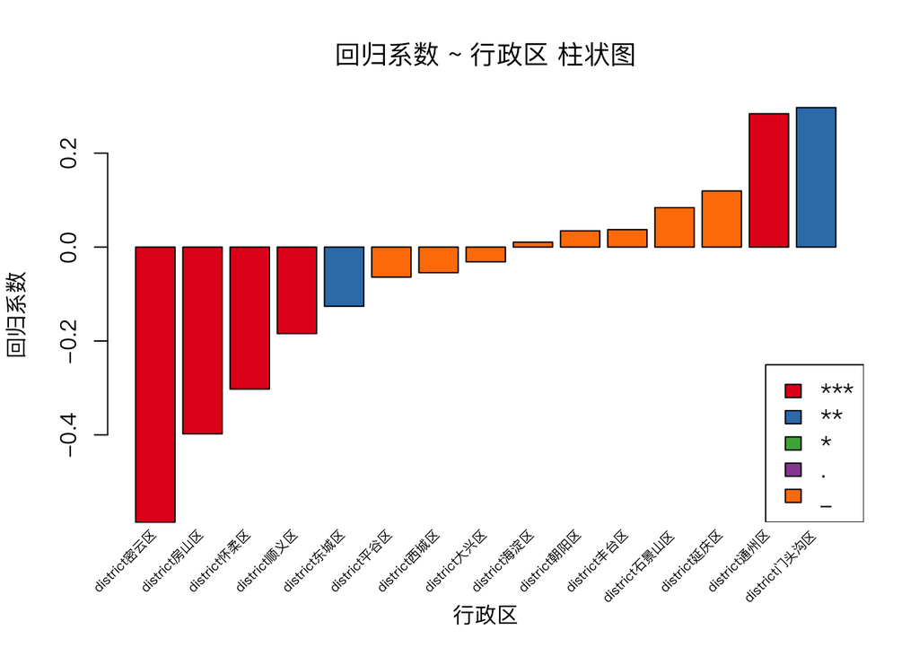

```r
coef_district = coef_district[order(coef_district$coef),]

coef_district$sig = cut(coef_district$p, breaks=c(0, .001, .01, .05, .1, 1), labels=c('***', '**', '*', '.', '_'))

par(family="PingFangSC-Regular")
library(RColorBrewer)
coul <- brewer.pal(5, "Set1")
coef_district$color = coul[coef_district$sig]

mp = barplot(coef_district$coef, col=coef_district$color, main = "回归系数 ~ 行政区 柱状图", xlab="行政区", ylab="回归系数",
             # legend.text=c('***', '**', '*', '.', '_'), args.legend=list(x="bottomright", fill=coul[1:5])
             )
legend("bottomright", legend=c('***', '**', '*', '.', '_'), fill=coul)
# 设置横坐标
lablist <- rownames(coef_district)
text(mp, par("usr")[3], labels = lablist, srt = 45, adj = c(1.1,1.1), xpd = TRUE, cex=0.6)
```

回归系数柱状图如上, 显著性水平用颜色显示了. 从图中可以看到, 密云区的回归系数最小, 门头沟区的系数最大.

7. 假设你要开一家外卖店，并有如下打算，请预测其未来的（已经不是新店）月销量。
1. 在长宁区经营快餐简餐（非品牌店），目标客户是学生党，平均每单费用约为20元（可参考北京与长宁区定位相似的行政区）；
2. 使用蜂鸟专送，配送费6元，配送时间约为45分钟；
3. 不可开发票；
4. 综合评分(new_score)约为0.65分；
5. 满减折扣率约为35%、其他活动数5个、没有新用户减免；
6. 每天营业11小时，且在18点和23点都营业。

```r
cnames = c("log_average_cost", "delivery_mode", "log_float_delivery_fee", "order_lead_time", "district", "保", "票", "manjian_discount", "other_activities", "open_time", "open18", "open23", "shop_type", "is_new", "is_premium")
new_shop = list(log(20), "蜂鸟专送", log(6), 45, "海淀区", T,F, 0.35, 5, 11, "1", "1", "快餐简餐", FALSE, FALSE)
test_data = as.data.frame(new_shop, col.names=cnames)
# test_data

logsalary_hat = predict.lm(model_bic, test_data)
# 对数线性回归需要进行调整
sigma_hat2 = sum(model_bic$residuals^2) / model_bic$df.residual  # sigma^2估计值
y_hat = exp(logsalary_hat + sigma_hat2/2)
cat("预计月销量约为", round(y_hat, 2))
```

```
## 预计月销量约为 1453.67
```

选择海淀区作为长宁区类似的行政区. 在上面的假定下, 模型预测的月销量约为1453份.